# Course Project 1

Federico Vera

11/10/2021

## 1)Loading and preprocesing the data

## 1_1 Load the Data

We take the URL of the data and put it on a local directory with a copy on Github, load the data into R

```r
# URL address of the data
URL <- "https://d396qusza40orc.cloudfront.net/repdata%2Fdata%2Factivity.zip"

# download the file
download.file(URL,destfile="./datastore/repdata_2Fdata_2Factivity.zip",method="auto")


# Unzip the file
unzip(zipfile="./datastore/repdata_2Fdata_2Factivity.zip",exdir="data")
```

## 1_2 Process/Transform the data into a format suitable for analysis

Cleaning the NA data

```r
data <- read.csv("data/activity.csv", header=TRUE)
clear_Data <- na.omit(data)
```

## 2) What is mean total number os steps taken per day?

## 2_1 Calculating Total number of steps per day

```r
steps_x_day <- aggregate(clear_Data$steps, by= list(Steps.Date= clear_Data$date), FUN = "sum")
```

## 2_2 Histogram of the total number os steps taken each day

plot the number of steps in the x axis, divided in 20 breaks, and the y shows the frecuency of how many days that quantity appear.

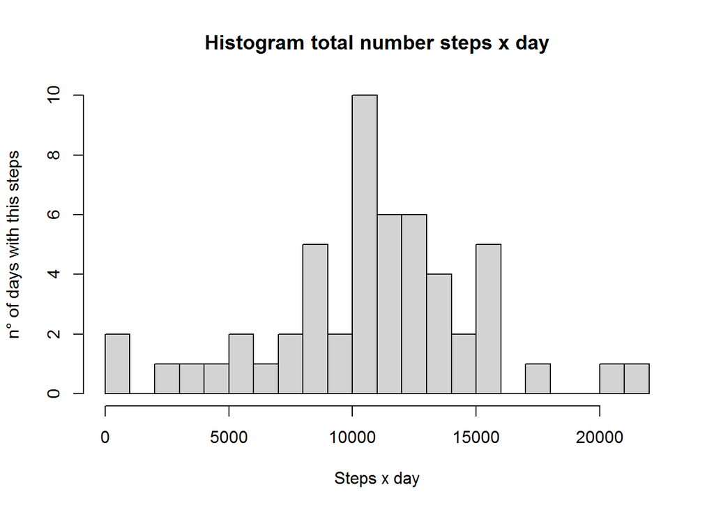

```r
hist(steps_x_day$x,
     breaks=20,
     main="Histogram total number steps x day",
     xlab= "Steps x day",
     ylab= "n° of days with this steps"
     )
```

## Calculating and reporting the mean and median of the total number of ##steps taken per day

```r
#Mean
mean(steps_x_day$x, na.rm=TRUE)
```

```
## [1] 10766.19
```

```r
#Median
median(steps_x_day$x, na.rm=TRUE)
```

```
## [1] 10765
```

## 3) What is the average daily activity pattern?

## 3-1 Make a time series plot of the 5 minute interval vs average number of steps taken

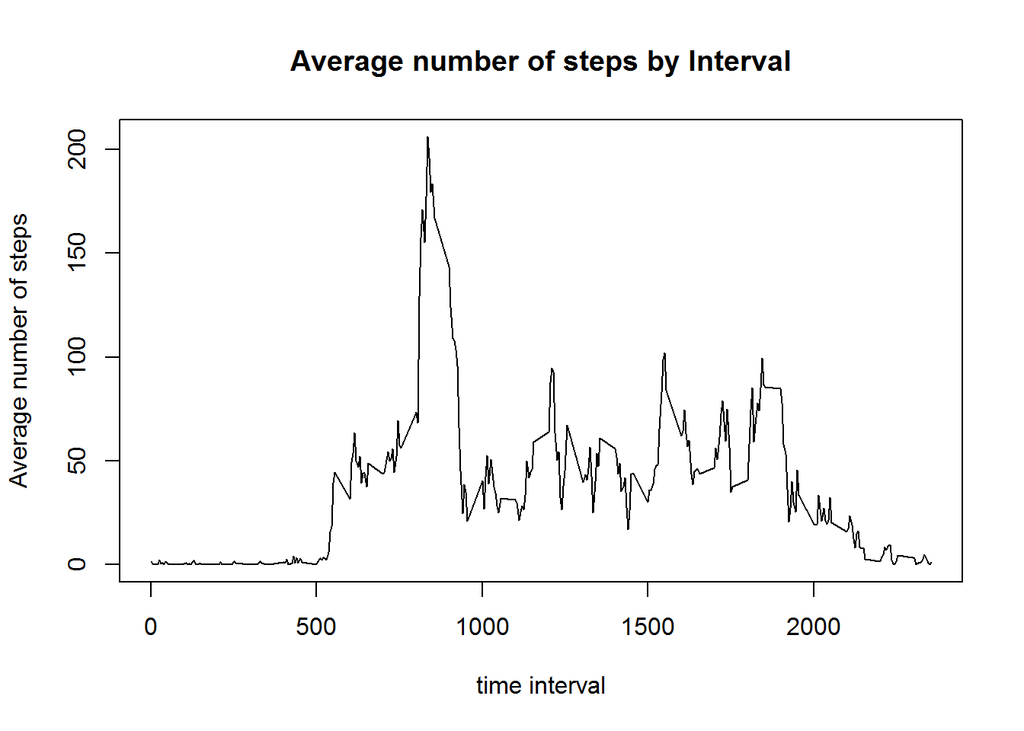

```r
avg_steps_x_interval <- aggregate(steps ~ interval, clear_Data, mean)

plot(avg_steps_x_interval$interval, avg_steps_x_interval$steps, type="l",
     col=1,
     main="Average number of steps by Interval",
     xlab="time interval",
     ylab="Average number of steps")
```

## 3_2 Which 5-minute interval, contains the maximum number of steps?

```r
max_interval <- which.max(avg_steps_x_interval$steps)

print (paste("The interval with the highest avg step is",avg_steps_x_interval[max_interval,]$interval," and the interval's step number is",round(avg_steps_x_interval[max_interval,]$steps, digits=1)))
```

```
## [1] "The interval with the highest avg step is 835  and the interval's step number is 206.2"
```

## 4) Imputing missing values

## 4_1 Calculate and report the total number os missing values

```r
missing_value_act <- data[!complete.cases(data),]
nrow(missing_value_act)
```

```
## [1] 2304
```

## 4_2 Devise a strategy for filling missing values in the dataset

# Im’ going to replace the missing values (NA) with the average 5 minute interval

```r
data$full_steps <- ifelse(is.na(data$steps), round(avg_steps_x_interval$steps[match(data$interval,avg_steps_x_interval$interval)
],0),data$steps)

head(data)
```

```
##   steps       date interval full_steps
## 1    NA 2012-10-01        0          2
## 2    NA 2012-10-01        5          0
## 3    NA 2012-10-01       10          0
## 4    NA 2012-10-01       15          0
## 5    NA 2012-10-01       20          0
## 6    NA 2012-10-01       25          2
```

## 4_3 Create a new dataset with the NA values filled

```r
# new dataframe

full_data <- data.frame(steps=data$full_steps, interval= data$interval, date= data$date)

head(full_data)
```

```
##   steps interval       date
## 1     2        0 2012-10-01
## 2     0        5 2012-10-01
## 3     0       10 2012-10-01
## 4     0       15 2012-10-01
## 5     0       20 2012-10-01
## 6     2       25 2012-10-01
```

## 4_4 Make a Histogram of the total number of steps taken each day

```r
full_steps_x_day <- aggregate(full_data$steps, by= list(Steps.Date= full_data$date), FUN = "sum")
```

plot the number of steps in the x axis, divided in 20 breaks, and the y shows the frecuency of how many days that quantity appear.

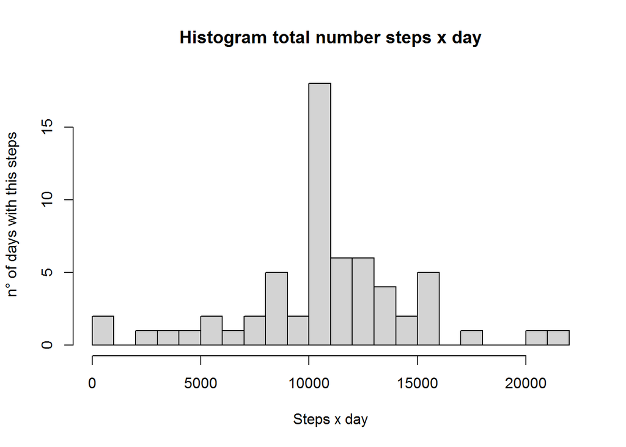

```r
hist(full_steps_x_day$x,
     breaks=20,
     main="Histogram total number steps x day",
     xlab= "Steps x day",
     ylab= "n° of days with this steps"
     )
```

Calculating the mean and median

```r
#Mean
mean(full_steps_x_day$x, na.rm=TRUE)
```

```
## [1] 10765.64
```

```r
#Median
median(full_steps_x_day$x, na.rm=TRUE)
```

```
## [1] 10762
```

```r
full_data$newDate <- as.Date(full_data$date, format = "%Y-%m-%d")

full_data$weekday <- weekdays(full_data$newDate)

full_data$day_type <- ifelse(full_data$weekday=='Saturday' |
full_data$weekday=='Sunday', 'weekend','weekday')

head(full_data, n=12)
```

```
##    steps interval       date    newDate weekday day_type
## 1      2        0 2012-10-01 2012-10-01   lunes  weekday
## 2      0        5 2012-10-01 2012-10-01   lunes  weekday
## 3      0       10 2012-10-01 2012-10-01   lunes  weekday
## 4      0       15 2012-10-01 2012-10-01   lunes  weekday
## 5      0       20 2012-10-01 2012-10-01   lunes  weekday
## 6      2       25 2012-10-01 2012-10-01   lunes  weekday
## 7      1       30 2012-10-01 2012-10-01   lunes  weekday
## 8      1       35 2012-10-01 2012-10-01   lunes  weekday
## 9      0       40 2012-10-01 2012-10-01   lunes  weekday
## 10     1       45 2012-10-01 2012-10-01   lunes  weekday
## 11     0       50 2012-10-01 2012-10-01   lunes  weekday
## 12     0       55 2012-10-01 2012-10-01   lunes  weekday
```

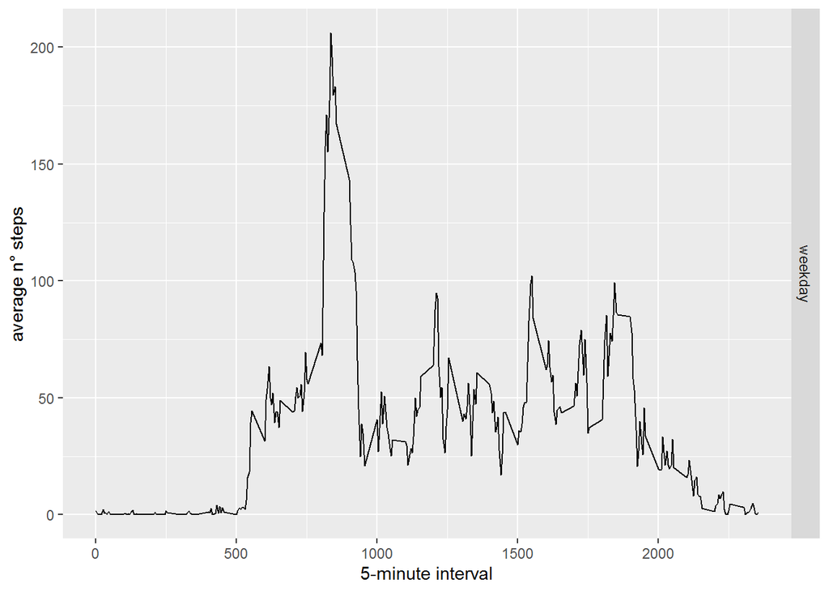

```r
library(ggplot2)

avg_full_data <- aggregate (steps ~ interval + day_type, data = full_data, mean)

ggplot(avg_full_data, aes(interval, steps))+
        geom_line()+
        facet_grid(day_type ~.)+
        xlab("5-minute interval")+
        ylab("average n° steps")
```